# Cocaine usage project

### Group 11

Members:

- Sam wang, 70602008
- Tia Murdoch, 719191378
- Hanna Ross, 40955320
- Maan Grover, 62953260

## Introduction

Cocaine is an illicit drug that belongs to the class of stimulants and is primarily administered through nasal inhalation. It is produced with derivatives from the coca plant, which is native to South America. In 2020, the United Nations reported that there were 21 million users of cocaine globally. Many researchers have begun to investigate the underlying indicators that make humans more susceptible to consuming illegal substances and to developing addiction.

For this project, we are interested in evaluating how one's demographics may predict the usage of cocaine. We are using a data set which was obtained from 1885 participants. The researchers looked at personality measurement attributes as well as demographic information while collecting their disclosed usage of 18 substances. We will be using the attributes of gender, age, education, ethnicity and country to predict whether someone may be a user of cocaine.

## Preliminary exploratory data analysis

```r
#load library
library(tidyverse)
library(tidymodels)
library(repr)
#set seed
set.seed(1)
```

```
• Learn how to get started at https://www.tidymodels.org/start/
```

```r
#read data set
drug_data <- read_csv("https://archive.ics.uci.edu/ml/machine-learning-databases/00373/drug_consumption.data",col_names = FALSE)
#select needed predictors and class
drug_data_selected <- drug_data |>
     select(X1:X6, X21)
```

```r
#make column names human readable
drug_data_clean <- drug_data_selected |>
       rename(identifier = X1, age = X2, gender = X3,
       education = X4, country = X5, ethnicity = X6,  cocaine_usage = X21)

#change column "use" into factor
drug_data_clean <- drug_data_clean |>
       mutate(cocaine_usage = as_factor(cocaine_usage))
```

Now the data is clean and in tidy format, we can print the data.

```r
#print data
print(drug_data_clean)
```

```
# A tibble: 1,885 × 7
   identifier     age gender education country ethnicity cocaine_usage
        <dbl>   <dbl>  <dbl>     <dbl>   <dbl>     <dbl> <fct>
 1          1  0.498   0.482   -0.0592   0.961     0.126 CL0
 2          2 -0.0785 -0.482    1.98     0.961    -0.317 CL3
 3          3  0.498  -0.482   -0.0592   0.961    -0.317 CL0
 4          4 -0.952   0.482    1.16     0.961    -0.317 CL2
 5          5  0.498   0.482    1.98     0.961    -0.317 CL0
 6          6  2.59    0.482   -1.23     0.249    -0.317 CL0
 7          7  1.09   -0.482    1.16    -0.570    -0.317 CL0
 8          8  0.498  -0.482   -1.74     0.961    -0.317 CL0
 9          9  0.498   0.482   -0.0592   0.249    -0.317 CL0
10         10  1.82   -0.482    1.16     0.961    -0.317 CL0
# … with 1,875 more rows
```

We split data into training and testing data with 75% being training data.

```r
#split data
drug_split <- initial_split(drug_data_clean, prop = 0.75, strata = cocaine_usage)
drug_train <- training(drug_split)
drug_test <- testing(drug_split)
```

### Summarize the data

To give an overview of the training data:

1. summarize the mean value for each predictors
2. count the number of observation for each class
3. find out number of missing row

```r
#summarize mean and number of observation in a table
data_summarize <- drug_train |>
    group_by(cocaine_usage) |>
    summarize(age_mean = mean(age), gender_mean = mean(gender), education_mean = mean(education),
              country_mean = mean(country), ethnicity_mean = mean(ethnicity), observations = n())
```

```r
data_summarize
```

A tibble: 7 × 7

| cocaine_usage <fct> | age_mean <dbl> | gender_mean <dbl> | education_mean <dbl> | country_mean <dbl> | ethnicity_mean <dbl> | observations <int> |
| --- | --- | --- | --- | --- | --- | --- |
| CL0 | 0.08069521 | 0.07518857 | 0.08976796 | 0.54467671 | -0.3244855 | 770 |
| CL3 | -0.36679808 | -0.15248736 | -0.19423446 | 0.03298254 | -0.2980445 | 193 |
| CL2 | 0.06026394 | -0.04386000 | -0.12849985 | 0.21472919 | -0.2984626 | 198 |
| CL1 | 0.81914862 | 0.00000000 | 0.10732654 | 0.27795869 | -0.3158266 | 130 |
| CL6 | -0.35953500 | -0.20676857 | -0.43469500 | 0.26158286 | -0.2544143 | 14 |
| CL5 | -0.52445562 | -0.15076875 | -0.09852656 | 0.17867500 | -0.3086403 | 32 |
| CL4 | -0.40598592 | -0.13965947 | -0.05339329 | -0.03978224 | -0.2760253 | 76 |

```r
#find out number of missing row
sum(is.na(drug_train))
```

0

There is no `na.` value in the data frame, which indicates there is zero number of missing rows.

### Visualize the data

Since our data is standardized, the scatter plot and regular bar plot don't present variable distribution very well. Instead we use the function "fill" to equalize the height of bar plot so we can compare the proportion of class based on different predictors, which allows us to find which variables are useful to distinguish whether a person may become a drug user.

```r
#Plot to see trend of use in variables
age_plot <- drug_train |>
    ggplot(aes(x = age, fill = cocaine_usage)) +
    geom_bar(width = 0.5, position = "fill") +
    xlab("Age from low to high, 18 to 65+ (standardized)") +
    ylab("Proportion") +
    theme(text = element_text(size = 15))

gender_plot <- drug_train |>
    ggplot(aes(x = gender, fill = cocaine_usage)) +
    geom_bar(position = "fill") +
    xlab("Gender: Male(left), Female(right)") +
    ylab("Proportion") +
    theme(text = element_text(size = 15))

education_plot <- drug_train |>
    ggplot(aes(x = education, fill = cocaine_usage)) +
    geom_bar(width = 0.2, position = "fill") +
    xlab("Education achievement low to high (standardized)") +
    ylab("Proportion") +
    theme(text = element_text(size = 15))

country_plot <- drug_train |>
    ggplot(aes(x = country, fill = cocaine_usage)) +
    geom_bar(width = 0.03, position = "fill") +
    xlab("Country (standardized)") +
    ylab("Proportion") +
    theme(text = element_text(size = 15))

ethnicity_plot <- drug_train |>
    ggplot(aes(x = ethnicity, fill = cocaine_usage)) +
    geom_bar(position = "fill") +
    xlab("Ethnicity (standardized)") +
    ylab("Proportion") +
    theme(text = element_text(size = 15))
```

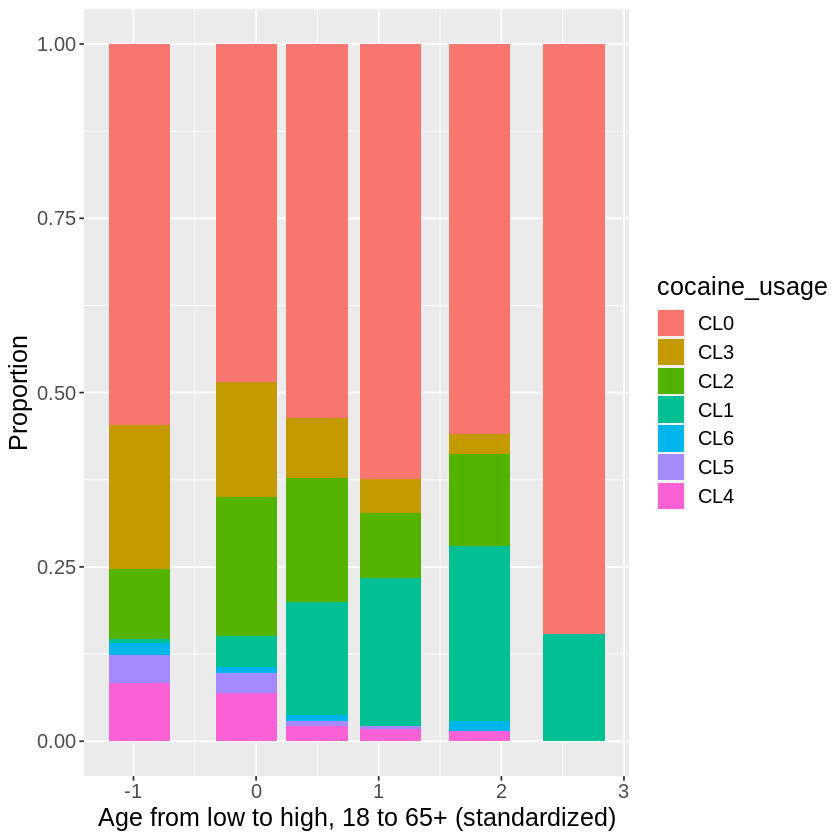

```r
age_plot
options(repr.plot.width = 10, repr.plot.height = 4)
```

As the plot shows, age is a strong indicator of being a cocaine user. The likelihood of being a cocaine user decreases as age increases.

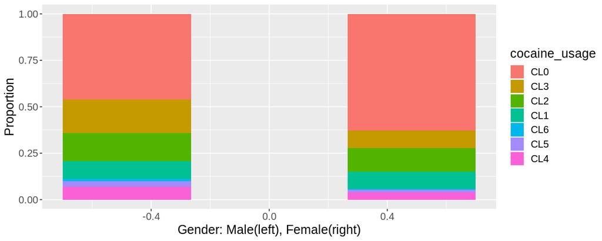

```r
gender_plot
options(repr.plot.width = 6, repr.plot.height = 4)
```

Gender is a strong indicator since being a male increases the chance of being a cocaine user.

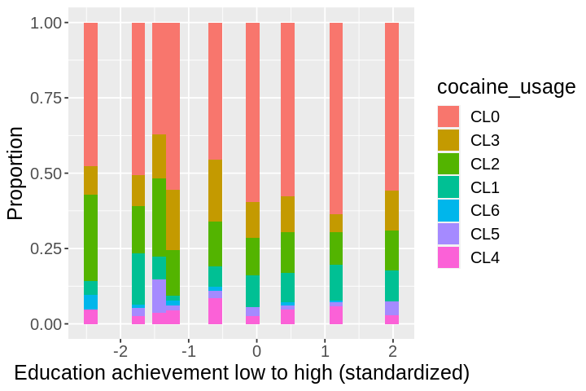

```r
education_plot
options(repr.plot.width = 12, repr.plot.height = 5)
```

As the plot shows, the education achievement tends to decrease drug consumption. With higher education level there are more people who have'never used' cocaine.

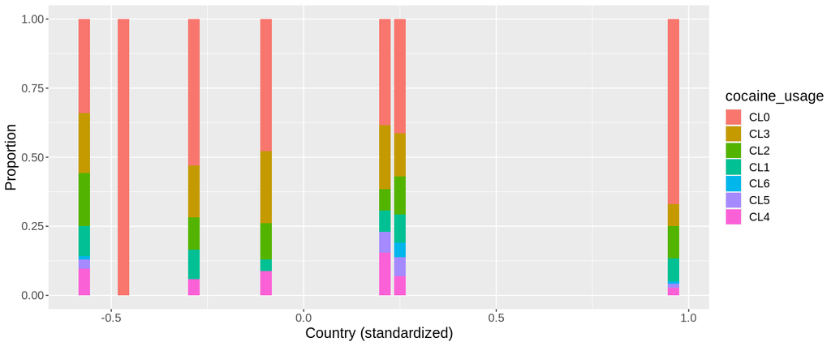

```r
country_plot
options(repr.plot.width = 10, repr.plot.height = 5)
```

As the plot shows, country affects whether a person may become cocaine user.

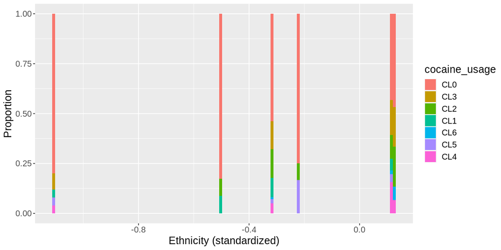

```r
ethnicity_plot
```

In conclusion of the above discussion, we decide to use `age`, `gender`, `education`, `country` and `ethnicity` as predictors.

## Expected outcomes and significance

The findings could also raise several questions for further research, such as:

- What historical events have led to greater usage of cocaine in certain demographics?
- Why does a higher degree of education make cocaine use less likely?
- How can public health initiatives more effectively reach groups that are more likely to use cocaine?
- Are there any additional racial or ethnic demographic characteristics that affect cocaine use?